# Explorer des textes longs avec R.temis

B. Garnier (Ined)

2022-06-27

# Statistique textuelle sur un corpus de discours

## Données

```r
library(R.temis)
```

## Importation du corpus et des métadonnées

Ici on utilise la mise en forme “Alceste” que l’on peut aussi utiliser avec IRaMuTeQ, Quanteda ou Rainette. Les métadonnées sont écrites en début de chaque texte ce qui permet de mettre tout dans un même fichier. En savoir plus sur cet format sur http://www.iramuteq.org/documentation/formatage-des-corpus-texte

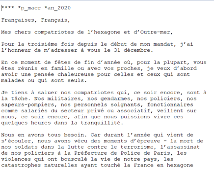

```r
corpus <- import_corpus("Corpus_voeux_fromGiscard.txt", format="alceste", language="fr")
```

Mais on peut aussi placer l’ensemble des textes dans un répertoire et les méta données dans un tableau (.csv)

[figure not shown]

On pourra alors les fusionner avec les fonctions suivantes `corpus <- import_corpus("Corpus_Voeux_Gis", format="txt", language="fr")` `don<-read.csv2("Data_Voeux_Gis.csv", header=TRUE)` `corpus <- set_corpus_variables(corpus, don)`

#affichage de la premiere unite de texte et des metadonnées

```r
inspect (corpus[[1]])
View(meta(corpus))
```

# Création du tableau lexical

```r
dtmsmo <-build_dtm(corpus, remove_stopwords = T )
dtmsmo
```

```
## <<DocumentTermMatrix (documents: 49, terms: 5830)>>
## Non-/sparse entries: 20172/265498
## Sparsity           : 93%
## Maximal term length: 19
## Weighting          : term frequency (tf)
```

Les lignes du *tableau lexical* correspondent ici aux 49 discours et les colonnes aux 5830 mots utilisés par les présidents.

# Explorer le lexique

On affiche les mots (ici termes) par ordre alphabétique ou par fréquence pour faire une première exploration des textes.

On peut afficher le dictionnaire dans une fenêtre de R Studio où on pourra le trier selon l’ordre alphabétique ou par fréquence des mots (pas exécuté ici) On peut exporter le dictionnaire en fichier csv (pas exécuté ici)

Le mots *France* est évoqué 412 fois dans l’ensemble des 49 discours, *travail* 90 fois.

## Nettoyage

On crée une liste de mots que l’on a choisi de supprimer du tableau lexical.

Ici, comme à tout moment de l’analyse, il est important d’aficher les *concordances* d’un mot pour ensuite faire un choix (le supprimer, interpréter, … ).

```r
#concordances(corpus,dtmsmo,"plus")
asupp <- c("parce","là","alors","aussi", "sais", "depuis", "dit", "tout", "être", "comme", "toutes", "car", "plus","faux", "vrai")
dtmsmo2 <-dtmsmo[, !colnames(dtmsmo)  %in% asupp]
```

# Afficher un nuage de mots

Le *nuage de mot* est une forme de *visualisation* du lexique associé au corpus.

On affiche les termes employés plus de 20 fois et 100 au maximum.

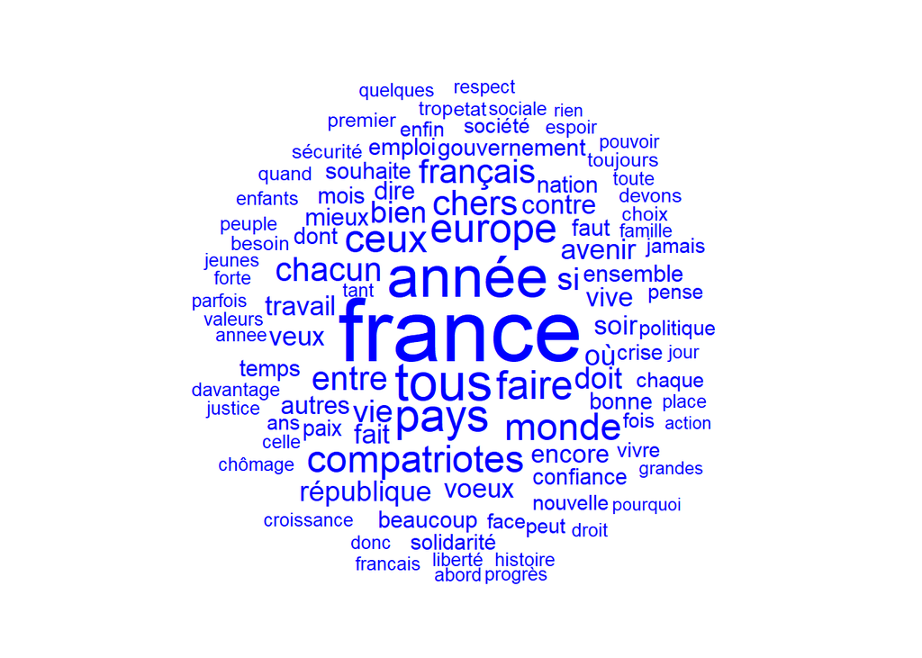

```r
cloud<-word_cloud(dtmsmo2, color="blue", n=100, min.freq=20)
```

### Elements d’habillage du nuage de mots

On calcule les *fréquences* de mots qui seront affichés dans la légende du nuage de mots.

```r
frequent_terms(dtmsmo2, n=30)
```

```
##              Global occ.  Global %
## france               412 1.4846312
## année                250 0.9008684
## tous                 221 0.7963677
## pays                 184 0.6630392
## europe               160 0.5765558
## faire                156 0.5621419
## ceux                 151 0.5441245
## compatriotes         145 0.5225037
## monde                145 0.5225037
## chers                130 0.4684516
## entre                123 0.4432273
## français             122 0.4396238
## chacun               117 0.4216064
## si                   110 0.3963821
## vie                  110 0.3963821
## doit                 104 0.3747613
## bien                 103 0.3711578
## où                    94 0.3387265
## avenir                93 0.3351231
## république            91 0.3279161
## travail               90 0.3243126
## contre                89 0.3207092
## fait                  89 0.3207092
## voeux                 87 0.3135022
## soir                  85 0.3062953
## veux                  84 0.3026918
## vive                  84 0.3026918
## encore                82 0.2954848
## autres                78 0.2810710
## dire                  78 0.2810710
```

# Partitionner le corpus

On choisit de partitionner le corpus en unités textuelles de 1 paragraphe qui deviendront les lignes du tableau lexical.

```r
corpus_d <-split_documents(corpus,1)
dtmsmo_d <-build_dtm(corpus_d, remove_stopwords=T)
dtmsmo_d2 <-dtmsmo_d[, !colnames(dtmsmo_d)  %in% asupp]
dtmsmo_d2
```

```
## <<DocumentTermMatrix (documents: 1335, terms: 5815)>>
## Non-/sparse entries: 25991/7737034
## Sparsity           : 100%
## Maximal term length: 19
## Weighting          : term frequency (tf)
```

Le tableau lexical génére croisant en ligne les 1335 paragraphes et en colonnes les 5815 termes puisqu’on a pas retenu les mots-outils et supprimé certains mots.

# Concordances

```r
#concordances(corpus_d,dtmsmo_d2,"crise")
concordances(corpus_d,dtmsmo_d2,"gagner")
```

```
## X5.22
## D’abord un vœu de vérité. Oui, nous souhaiter en 2019 de ne pas oublier qu’on ne bâtit rien sur des mensonges ou des ambiguïtés. Or, je dois bien dire que depuis des années, nous nous sommes installés dans un déni parfois fragrant de réalité. On ne peut pas travailler moins, gagner plus, baisser …
## X5.81
## D’abord un vœu de vérité. Oui, nous souhaiter en 2019 de ne pas oublier qu’on ne bâtit rien sur des mensonges ou des ambiguïtés. Or, je dois bien dire que depuis des années, nous nous sommes installés dans un déni parfois fragrant de réalité. On ne peut pas travailler moins, gagner plus, baisser …
## X6.10
## Mais c'est la paix qu'il nous faut aussi gagner à l'international, c'est-à-dire ce travail indispensable pour notre sécurité mais aussi parce qu'il est notre mission universelle, ce travail pour garantir la stabilité des Etats et assurer le respect de toutes les minorités. C'est ce que nous avons…
## X6.14
## Je veux ensuite miser sur le travail. Le travail est au coeur de notre société d'abord parce qu'il est ce qui permet à chacun de trouver sa place, de progresser dans la vie, de s'émanciper de son milieu d'origine si c'est la volonté que chacun porte mais c'est aussi par le travail que notre Natio…
## X10.18
## En 2014, nous aurons besoin de la mobilisation de tous pour gagner cette bataille.
## X15.17
## Je pense aussi à la réforme du lycée qui est nécessaire pour éviter l'échec de tant de nos enfants dans l'enseignement supérieur et l'injustice qui fait que tant de fils et de filles, de familles modestes n'ont pas les mêmes chances que les autres. J'ai demandé que soit pris le temps de la concer…
## X18.6
## Mais 2005 a aussi été une année de succès pour la France. Avec l'A380 d'Airbus, avec Ariane 5, avec le système de navigation par satellite Galileo, avec Iter pour l'énergie du futur, notre pays s'est porté à la pointe de l'innovation mondiale. La croissance est repartie. Et surtout, nous avons ma…
## X19.21
## Tout faire pour la croissance. Poursuivre la hausse du SMIC et soutenir le pouvoir d'achat. Poursuivre la baisse de l'impôt sur le revenu et la baisse des charges. Continuer à maîtriser nos dépenses. Encourager l'investissement en mettant en oeuvre la réforme de la taxe professionnelle. Permettre…
## X25.9
## Aux responsables publics, vous demandez, d'abord, du courage, le courage de dire, le courage de faire, le courage de changer et d'assumer. Nous avons tout à gagner à poser franchement les problèmes. Tout le monde sait ce qui marche bien et ce qui marche moins bien en France. En dépit d'immenses p…
## X35.14
## - Mes chers compatriotes, dans cette perspective je vous dis bonne année. En dépit des drames qui l'ont traversée, 1988 a vu la paix et le désarmement gagner du terrain sur la guerre. L'espoir grandit d'une ère nouvelle. Puisse 1989 justifier cet espoir.
## X38.9
## - Croyez-moi, un peuple, pour être grand, doit être solidaire. Eh bien, il faut continuer. Surtout, ne lâchons pas la rampe. Ce sera difficile, encore, mais nous finirons par gagner.
## X42.11
## - Pour gagner la bataille de l'emploi, j'attends de tous les Français qu'ils mobilisent leurs facultés d'énergie d'initiative et d'-entreprise et j'attends du gouvernement qu'il leur en donne les moyens.
```

```r
concordances(corpus_d,dtmsmo_d2,"quinquennat")
```

```
## X10.28
## Nous devons dépenser moins pour réduire notre déficit mais aussi pour pouvoir, à terme, baisser les impôts. C’est là le sens de la réforme fiscale que nous avons engagée. J’assumerai, moi-même, la responsabilité et le suivi de ce programme d'économies durant tout le quinquennat.
```

# AFC sur Tableau Lexical

On affiche le plan (4,5) car les premiers axes correspondent aux paragraphes communs des discours (“mes chers compatriotes, Vive la France, etc …)

```r
resTLE<-corpus_ca(corpus_d,dtmsmo_d2,sparsity=0.98)
```

```
## 38 documents have been skipped because they do not include any occurrence of the terms retained in the final document-term matrix. Increase the value of the 'sparsity' parameter if you want to include them. These documents are: X2.40, X3.39, X4.11, X5.7, X5.31, X5.34, X5.57, X5.58, X5.66, X5.90, …
```

```r
#explor(resTLE)
res <- explor::prepare_results(resTLE)
explor::CA_var_plot(res, xax = 4, yax = 5, lev_sup = FALSE, var_sup = FALSE,
    var_sup_choice = , var_hide = "Row", var_lab_min_contrib = 0, col_var = "Position",
    symbol_var = "Type", size_var = NULL, size_range = c(10, 300), labels_size = 10,
    point_size = 56, transitions = TRUE, labels_positions = NULL, xlim = c(-2.6,
        4.05), ylim = c(-2.75, 3.91))
```

[interactive chart not shown]

# Réduire la taille du lexique : Lemmatiser

On regroupe des mots qui ont une signification proche : les verbes congugués à la forme infinitive, les formes plurielles au singulier, les adjectifs du féminin au masculin. Cette opération permet de réduire la liste de mots distincts.On voit ici comment créer son *lemmatiseur*.

On crée un *dictionnaire* associé au lexique avec la fonction `dictionnary`sans les mots-outils et les mots que l’on a choisit de ne pas analyser.

```r
#dictionary(dtm)
dic <-dictionary(dtmsmo)
dic2 <- dic[!rownames(dic) %in% asupp,]
```

Pour créér son propre lemmatiseur, on exporte ce dictionnaire de R (ici dic2_voeux.csv) pour pouvoir le modifier avec un tableur.

On a remplacé les stemmes des mots proposés par la lemmatisation automatique (colonne Term) par des mots que l’on choisit et enregisté ce dictionnaire retravaillé avec un autre nom (dic2l_voeux_Gis.csv).

On importe ce lemmatiseur dans R.

```r
dic3 <- read.csv2("dic2l_voeux_Gis.csv", row.names=1)
```

La deuxième étape de la lemmatisation avec R temis consiste à remplacer les mots initiaux par les mots lemmatisés avec la fonction `combine_terms`. Ici on va lemmatiser le tableau lexical constitué des unités de textes initiales (les 49 discours) et le tableau lexical des discours découpés en paragraphes.

```r
#setdiff(rownames(dic3), rownames(dic2))
dtmsmo2l <- combine_terms(dtmsmo2,dic3)
dtmsmo_d2l <- combine_terms(dtmsmo_d2,dic3)
```

# Les cooccurrences

## Avec un mots “au choix”

```r
cooc_terms(dtmsmo_d2l,"retraite",n = 10)
```

```
##          % Term/Cooc. % Cooc./Term   Global % Cooc. Global  t value  Prob.
## retraite    2.3076923    100.00000 0.06488591    18     18      Inf 0.0000
## pension     0.5128205    100.00000 0.01441909     4      4 4.849024 0.0000
## maison      0.6410256     50.00000 0.03604773     5     10 4.471250 0.0000
## travail     1.5384615     13.33333 0.32442954    12     90 4.307501 0.0000
## réform      1.2820513     14.49275 0.24872932    10     69 4.083747 0.0000
## system      0.7692308     26.08696 0.08290977     6     23 3.993954 0.0000
## quiconqu    0.3846154     75.00000 0.01441909     3      4 3.754851 0.0001
## gendarm     0.5128205     36.36364 0.03965250     4     11 3.575475 0.0002
## assur       0.7692308     16.66667 0.12977182     6     36 3.314321 0.0005
## an          1.1538462     10.46512 0.31001045     9     86 3.194894 0.0007
```

# Bilan lexical

Taille du corpus selon les métadonnées (nom du président) et de l’ensemble

```r
lexical_summary(dtmsmo2l, corpus, "president", unit="global")
```

```
##
## Per category total:               Chirac GiscardDEstaing     Hollande
##   Number of terms            6608.000000     2722.000000  3122.000000
##   Number of unique terms     1655.000000     1046.000000  1240.000000
##   Percent of unique terms      25.045400       38.427627    39.718129
##   Number of hapax legomena    752.000000      577.000000   667.000000
##   Percent of hapax legomena    11.380145       21.197649    21.364510
##   Number of words           12897.000000     5658.000000  6407.000000
##
## Per category total:               Macron   Mitterrand      Sarkozy Corpus total
##   Number of terms            7102.000000  5385.000000  2802.000000 27741.000000
##   Number of unique terms     1521.000000  1644.000000  1071.000000  3571.000000
##   Percent of unique terms      21.416502    30.529248    38.222698    12.872643
##   Number of hapax legomena    404.000000   733.000000   571.000000  1255.000000
##   Percent of hapax legomena     5.688538    13.611885    20.378301     4.523990
##   Number of words           14435.000000 10489.000000  5623.000000 55509.000000
```

Les discours du président Chirac contiennent le plus de mots différents et Giscard le moins.

# Spécificités

On affiche ici les mots specifiques utilisés par chaque président.

```r
specific_terms(dtmsmo2l,meta(corpus)$president, n = 10)
```

```
## $Chirac
##         % Term/Level % Level/Term   Global % Level Global occ.   t value  Prob.
## solidar    0.5145278     51.51515 0.23791500    34          66  4.749245 0.0000
## dynam      0.1513317     90.90909 0.03965250    10          11  4.415282 0.0000
## emploi     0.5145278     48.57143 0.25233409    34          70  4.391164 0.0000
## progres    0.3329298     56.41026 0.14058614    22          39  4.215382 0.0000
## ambit      0.2723971     62.06897 0.10453841    18          29  4.211442 0.0000
## aven       0.6204600     44.08602 0.33524386    41          93  4.195727 0.0000
## autor      0.1059322    100.00000 0.02523341     7           7  3.924753 0.0000
## mobilis    0.2875303     55.88235 0.12256227    19          34  3.853402 0.0001
## garant     0.2269976     62.50000 0.08651455    15          24  3.842370 0.0001
## -------           NA           NA         NA    NA          NA        NA     NA
## anne       0.0000000      0.00000 0.16581955     0          46 -4.486108 0.0000
##
## $GiscardDEstaing
##           % Term/Level % Level/Term   Global % Level Global occ.  t value Prob.
## anne         1.6899339    100.00000 0.16581955    46          46      Inf     0
## francais     0.6245408    100.00000 0.06128114    17          17      Inf     0
## voeux        1.3225569     41.37931 0.31361523    36          87 7.656574     0
## bonheur      0.6980162     70.37037 0.09732886    19          27 7.401594     0
## ete          0.4408523    100.00000 0.04325727    12          12 7.069179     0
## mem          0.4408523    100.00000 0.04325727    12          12 7.069179     0
## franc        4.0778839     19.20415 2.08355863   111         578 6.856056     0
## etre         0.3673769     90.90909 0.03965250    10          11 6.030586     0
## fraternit    0.3306392    100.00000 0.03244295     9           9 6.027394     0
## souhait      0.9919177     33.75000 0.28838182    27          80 5.748052     0
##
## $Hollande
##         % Term/Level % Level/Term   Global % Level Global occ.   t value  Prob.
## salu      0.22421525   53.8461538 0.04686205     7          13  3.526850 0.0002
## syr       0.16015375   71.4285714 0.02523341     5           7  3.422148 0.0003
## va        0.35233824   35.4838710 0.11174795    11          31  3.385353 0.0004
## fac       0.51249199   28.0701754 0.20547204    16          57  3.351793 0.0004
## terror    0.28827675   39.1304348 0.08290977     9          23  3.272086 0.0005
## état      0.19218450   54.5454545 0.03965250     6          11  3.256140 0.0006
## énerget   0.12812300   80.0000000 0.01802386     4           5  3.183036 0.0007
## utilis    0.12812300   80.0000000 0.01802386     4           5  3.183036 0.0007
## embauch   0.16015375   62.5000000 0.02883818     5           8  3.174197 0.0008
## -------           NA           NA         NA    NA          NA        NA     NA
## autr      0.03203075    0.9009009 0.40012977     1         111 -4.047831 0.0000
```

[output cut: 27 more lines]

```
## chacun     0.1485608     5.517241 0.52269204     8         145 -4.679474 0.0000
##
## $Sarkozy
##         % Term/Level % Level/Term   Global % Level Global occ.   t value  Prob.
## urgenc    0.42826552    66.666667 0.06488591    12          18  5.588851 0.0000
## cris      0.85653105    35.820896 0.24151977    24          67  5.543458 0.0000
## financi   0.39257673    64.705882 0.06128114    11          17  5.250069 0.0000
## grâc      0.42826552    33.333333 0.12977182    12          36  3.641373 0.0001
## proteg    0.46395432    30.952381 0.15140045    13          42  3.584424 0.0002
## ceux      1.07066381    19.867550 0.54432068    30         151  3.502828 0.0002
## financ    0.21413276    54.545455 0.03965250     6          11  3.421563 0.0003
## réform    0.60670949    24.637681 0.24872932    17          69  3.353629 0.0004
## doulour   0.14275517    80.000000 0.01802386     4           5  3.303458 0.0005
## -------           NA           NA         NA    NA          NA        NA     NA
## contr     0.03568879     1.123596 0.32082477     1          89 -3.144376 0.0008
```

Les mots *Vaccin, Virus ou soignants* sontt specifiques à Macron. Alors que *urgence, ou crise* sont spécifiques à Sarkozy.

On peut créer des sous-corpus en fonction des métadonnées. Ici par exemple on va selectionner les discours du président Macron

## Et pour aller plus loin

On peut créer des sous corpus à l’aide des métadonnées. Ici par exemple par les discours du président Macron

```r
#View(meta(corpus_d))
corpus_d_Macron <- corpus[meta(corpus_d, "president") == "Macron"]
```

# Classification avec Rainette

On fait une classification des textes découpés avec la package `Rainette`. En savoir plus sur  
https://juba.github.io/rainette/articles/introduction_usage.html Son utilisation nesessite aussi d’appeler le package `quanteda`.

```r
library(rainette)
library(quanteda)
corpus
```

```
## <<VCorpus>>
## Metadata:  corpus specific: 1, document level (indexed): 2
## Content:  documents: 49
```

```r
#on adapte le TLE pour quanteda
dfm <- as.dfm(dtmsmo_d2l)
resrai <- rainette(dfm,  k = 10)
```

```
##   Clustering...
```

```
##   Done.
```

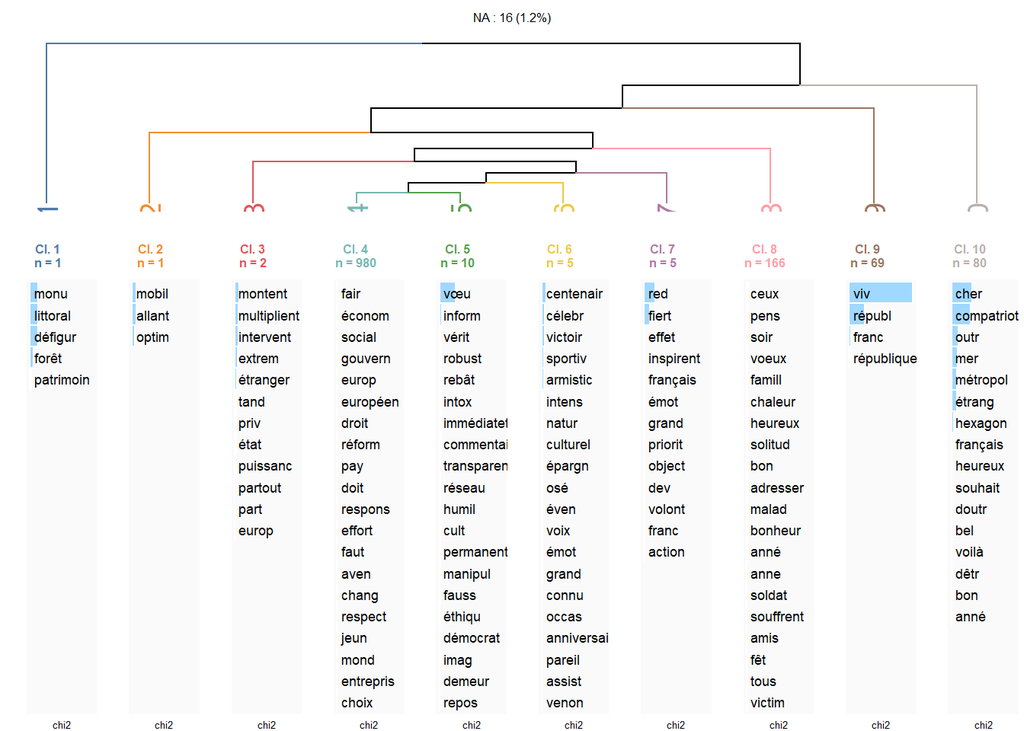

```r
#rainette_explor(resrai, dfm)
rainette_plot(
  resrai, dfm, k = 10,
  n_terms = 20,
  free_scales = FALSE,
  measure = "chi2",
  show_negative = FALSE,
  text_size = 6
)
```

```r
## Groups
#cutree_rainette(resrai, k = 10)
```